# Ques 1. Flights at ABIA

## 1) What is the best time of day to fly to minimize delays?

Considering the departure delays:I make a heat map across the days of the week and the time of the day over the 1 yeardata and aggregate over the departure delay.

```r
setwd("C:/Users/Sanchit/OneDrive/Github/STA380 - 08132015/STA380-master/data")
```

```r
airports= read.csv('ABIA.csv')
attach(airports)
airports$DepTime_hour=as.integer(DepTime/100)
airports$ArrTime_hour=as.integer(ArrTime/100)

names(airports)
```

```
##  [1] "Year"              "Month"             "DayofMonth"
##  [4] "DayOfWeek"         "DepTime"           "CRSDepTime"
##  [7] "ArrTime"           "CRSArrTime"        "UniqueCarrier"
## [10] "FlightNum"         "TailNum"           "ActualElapsedTime"
## [13] "CRSElapsedTime"    "AirTime"           "ArrDelay"
## [16] "DepDelay"          "Origin"            "Dest"
## [19] "Distance"          "TaxiIn"            "TaxiOut"
## [22] "Cancelled"         "CancellationCode"  "Diverted"
## [25] "CarrierDelay"      "WeatherDelay"      "NASDelay"
## [28] "SecurityDelay"     "LateAircraftDelay" "DepTime_hour"
## [31] "ArrTime_hour"
```

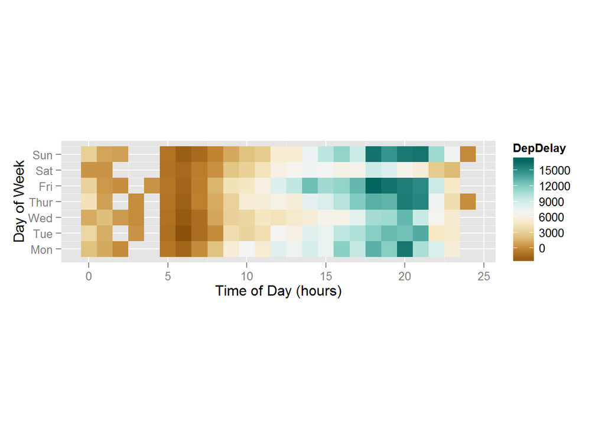

```r
dep_agg<- aggregate(DepDelay~DayOfWeek+DepTime_hour,airports,FUN='sum')
library(ggplot2)
library(RColorBrewer)
ggplot(dep_agg, aes(DepTime_hour,y=DayOfWeek))+
  geom_tile(aes(fill=DepDelay))+
  scale_fill_gradientn(colours=brewer.pal(9,"BrBG"),
                       breaks=seq(0,max(dep_agg$DepDelay),by=3000))+
  scale_y_continuous(breaks=7:1,labels=c("Sun","Sat","Fri","Thur","Wed","Tue","Mon"))+
  labs(x="Time of Day (hours)", y="Day of Week")+ coord_fixed()
```

## Analysis :

The best time of the day to fly to minimize the departure delay is during the early morning hours between 3am till 7 am as denoted by the low intensity of the heat map during these times

As the day progresses, the departure delay starts to increase and reaches the maximum during evening hours of 7 pm and 9pm (denoted in the heatmap as 19 and 21 hours)

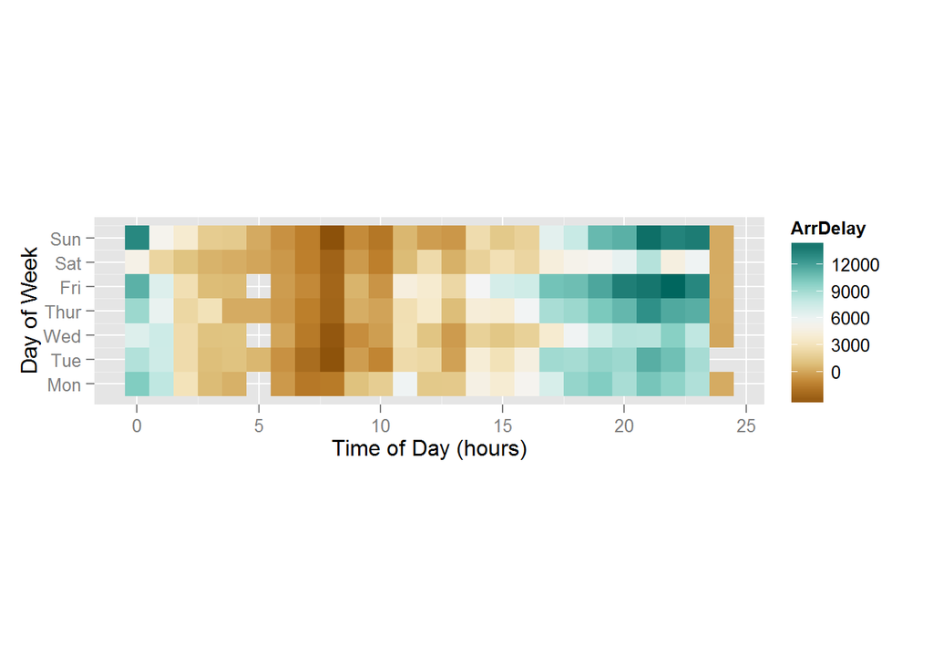

```r
dep_agg<- aggregate(ArrDelay~DayOfWeek+ArrTime_hour,airports,FUN='sum')
library(ggplot2)
library(RColorBrewer)
ggplot(dep_agg, aes(ArrTime_hour,y=DayOfWeek))+
  geom_tile(aes(fill=ArrDelay))+
  scale_fill_gradientn(colours=brewer.pal(9,"BrBG"),
                       breaks=seq(0,max(dep_agg$ArrDelay),by=3000))+
  scale_y_continuous(breaks=7:1,labels=c("Sun","Sat","Fri","Thur","Wed","Tue","Mon"))+
  labs(x="Time of Day (hours)", y="Day of Week")+ coord_fixed()
```

## Analysis:

The best time of the day to fly to minimize the arrival delay is during the morning hours between 3 am till 10 am and again after that between 12 noon and 1 pm

As the day progresses,the arrival delay starts to increase and reaches the maximum during evening hours of 8 pm and12 midnight (denoted in the heatmap as 20 and 24 hours)

## 2) What is the best time of year to fly to minimize delays?

Considering the arrival delays firstly,I again plot a heatmap to analyse the delays across the months and days

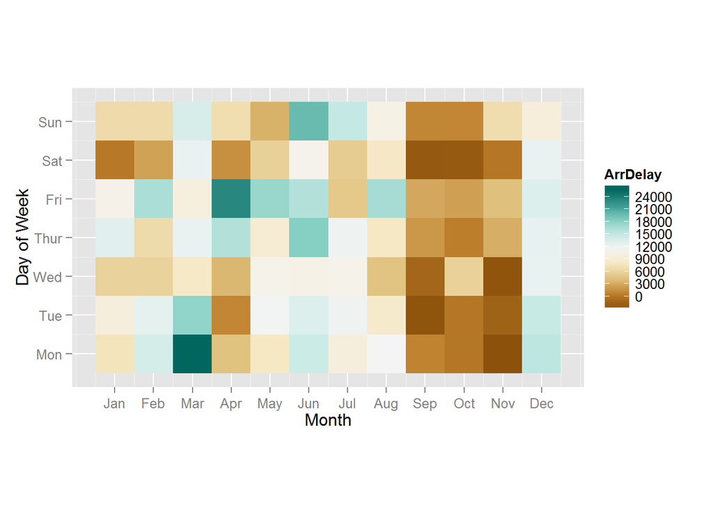

```r
arr_agg_month<- aggregate(ArrDelay~DayOfWeek+Month,airports,FUN='sum')

ggplot(arr_agg_month, aes(Month,y=DayOfWeek))+
  geom_tile(aes(fill=ArrDelay))+
  scale_fill_gradientn(colours=brewer.pal(9,"BrBG"),
                       breaks=seq(0,max(arr_agg_month$ArrDelay),by=3000))+
  scale_y_continuous(breaks=7:1,labels=c("Sun","Sat","Fri","Thur","Wed","Tue","Mon"))+
  scale_x_continuous(breaks=1:12, labels=c("Jan","Feb","Mar","Apr","May","Jun","Jul","Aug","Sep","Oct","Nov","Dec"))+
  labs(x="Month", y="Day of Week")+ coord_fixed()
```

## Analysis :

While the in the Month of March, there were significant arrival delays on Monday.Similarly, in the month ofApril,Friday sees a significant amount of arrival delay##

Then, I consider the departure delays and again plot a heatmap to analyse the delays across the months and days

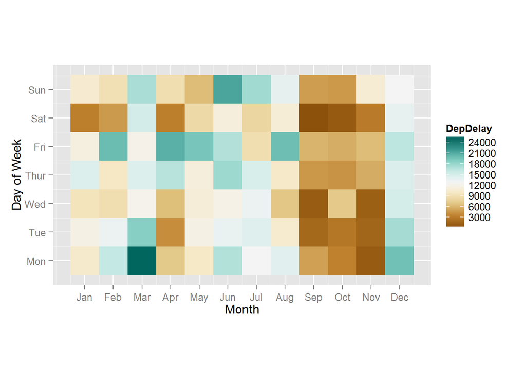

```r
Dep_agg_month<-aggregate(DepDelay~DayOfWeek+Month,airports,FUN='sum')

ggplot(Dep_agg_month, aes(Month,y=DayOfWeek))+
  geom_tile(aes(fill=DepDelay))+
  scale_fill_gradientn(colours=brewer.pal(9,"BrBG"),
                       breaks=seq(0,max(Dep_agg_month$DepDelay),by=3000))+
  scale_y_continuous(breaks=7:1,labels=c("Sun","Sat","Fri","Thur","Wed","Tue","Mon"))+ scale_x_continuous(breaks=1:12, labels=c("Jan","Feb","Mar","Apr","May","Jun","Jul","Aug","Sep","Oct","Nov","Dec"))+
  labs(x="Month", y="Day of Week")+ coord_fixed()
```

## Analysis :

The best time of year to fly to minimize departure delay are in the months of September,October and November

## 3) How do patterns of flights to different destinations or parts of the country change over the course of ##the year?

For this problem, I plot the different airport cities over the geographic map according to the coordinates of the city airport.Then I aggregate on the number of flights departing from each city airport and the size of the size of the dots correspond to the number of departing flights from that city airport.

```
##     Origin_City Origin_Latitude Origin_Longitude flights
## 1 San Francisco        37.61897        -122.3749     609
## 2       Seattle        47.44900        -122.3093     147
## 3       Oakland        37.72128        -122.2207     236
## 4      San Jose        37.36260        -121.9290     968
## 5   Los Angeles        33.94254        -118.4081    1732
## 6    Long Beach        33.81772        -118.1516     245
```

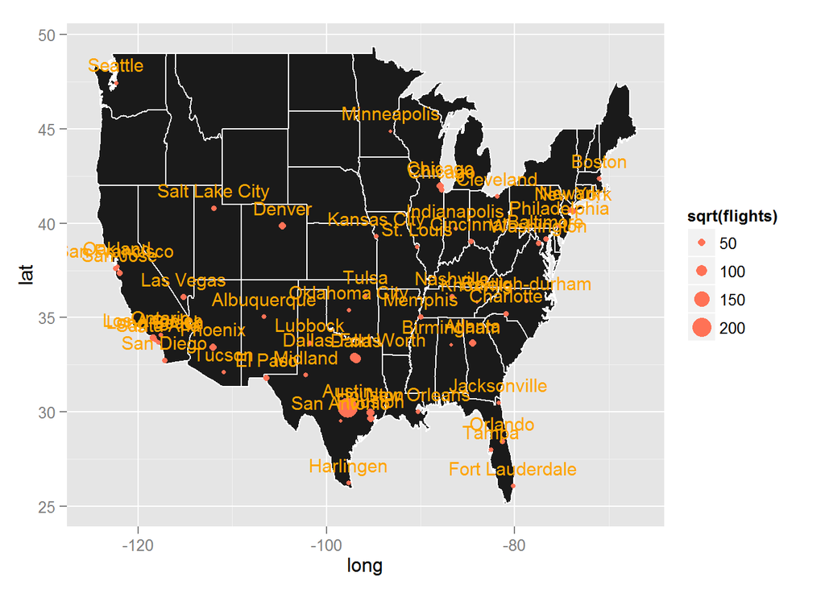

## Analysis

Austin, Dallas, Denver, Phoenix, El Paso see a high volume of flights over the course of the year while Salt Lake City, Minneapolis,Nashville etc have a realtively low volume of flights

# Ques 2. Author attribution

## Model 1:Applying Naives Bayes Model

The code below is used to roll the documents from the directory below into 50 corpora and each representing the documents written by 50 different authors

```r
library(tm)
```

```r
author_dirs = Sys.glob('../data/ReutersC50/C50train/*')
    author_dirs = author_dirs[1:50]
    file_list = NULL
    labels = NULL
    for(author in author_dirs) {
      author_name = substring(author, first=29)
      files_to_add = Sys.glob(paste0(author, '/*.txt'))
      file_list = append(file_list, files_to_add)
      labels = append(labels, rep(author_name, length(files_to_add)))
    }

    readerPlain = function(fname){
                readPlain(elem=list(content=readLines(fname)),
                            id=fname,
                            language='en') }
```

The snippet below stores the contents of documents in the my_corpus variable and the code also retrieves the files names for each corpus and assigns it to the corresponding corpus.

[output not shown]

The data in the documents are preprocessed and the following transformations are made - make the documentlowercase,remove numbers, remove punctutations, remove excess white-space and ‘SMART’ stopwords are removed.

```r
    # Preprocessing
    my_corpus = tm_map(my_corpus, content_transformer(tolower)) # make everything lowercase
    my_corpus = tm_map(my_corpus, content_transformer(removeNumbers)) # remove numbers
    my_corpus = tm_map(my_corpus, content_transformer(removePunctuation)) # remove punctuation
    my_corpus = tm_map(my_corpus, content_transformer(stripWhitespace)) ## remove excess white-space
    my_corpus = tm_map(my_corpus, content_transformer(removeWords), stopwords("SMART"))

    DTM = DocumentTermMatrix(my_corpus)

    class(DTM)  # a special kind of sparse matrix format
```

```
## [1] "DocumentTermMatrix"    "simple_triplet_matrix"
```

```r
    DTM = removeSparseTerms(DTM, 0.945)
```

Creating a dense matrix from a sparse matrix as some function will not work on sparse matrix. The con side is that we are wasting memory space.

```r
    # Now a dense matrix
    X = as.matrix(DTM)
```

Creating the multinomial probability vector for each of the 50 authors using the smoothing factor to account for the occurences of a word that is not available in training corpus.

```r
    w <- list()
    smooth_count = 1/nrow(X)
    for(i in 0:49) {
      w[[i+1]] = colSums(X[(i*50+1):((i+1)*50),] + smooth_count)
      w[[i+1]] = w[[i+1]]/sum(w[[i+1]])
    }
```

The code below is used to roll the test documents from the directory below into 50 corpora and each representing the documents written by 50 different authors

```r
    #Let's take a specific test document
    #Getting the X matrix for the test documents
    author_dirs = Sys.glob('../data/ReutersC50/C50test/*')
    author_dirs = author_dirs[1:50]
    file_list = NULL
    labels = NULL
    for(author in author_dirs) {
      author_name = substring(author, first=28)
      files_to_add = Sys.glob(paste0(author, '/*.txt'))
      file_list = append(file_list, files_to_add)
      labels = append(labels, rep(author_name, length(files_to_add)))
    }
```

The snippet below stores the contents of test documents in the my_corpus variable and the code also retrieves the files names for each corpus and assigns it to the corresponding corpus.

```r
    # Need a more clever regex to get better names here
    all_docs = lapply(file_list, readerPlain)
    names(all_docs) = file_list
    names(all_docs) = sub('.txt', '', names(all_docs))
    my_corpus = Corpus(VectorSource(all_docs))
    names(my_corpus) = file_list
```

The data in the test documents are preprocessed and the following transformations are made - make thedocument lowercase,remove numbers, remove punctutations, remove excess white-space and ‘SMART’ stopwords are removed.

```r
    # Preprocessing
    my_corpus = tm_map(my_corpus, content_transformer(tolower)) # make everything lowercase
    my_corpus = tm_map(my_corpus, content_transformer(removeNumbers)) # remove numbers
    my_corpus = tm_map(my_corpus, content_transformer(removePunctuation)) # remove punctuation
    my_corpus = tm_map(my_corpus, content_transformer(stripWhitespace)) ## remove excess white-space
    my_corpus = tm_map(my_corpus, content_transformer(removeWords), stopwords("SMART"))

    DTM = DocumentTermMatrix(my_corpus)

    class(DTM)  # a special kind of sparse matrix format
```

```
## [1] "DocumentTermMatrix"    "simple_triplet_matrix"
```

```r
    DTM = removeSparseTerms(DTM, 0.945)
```

Now we will test each document from the test data document matrix which is of size 50*50 against each author’sdocuments and later comparing the calculated log probabilities under the Naives Bayes Model and returning the maximum summed value.The author’s index corresponding to this maximum value will be stored.

Like this, all the 2500 documents will be checked.

```r
    # Now a dense matrix
    X_test = as.matrix(DTM)

    head(sort(X_test, decreasing=TRUE), 25)
```

```
##  [1] 31 30 27 27 26 26 25 25 24 24 24 23 23 22 22 22 22 22 22 22 21 21 21
## [24] 21 21
```

```r
    c <- as.array(NA, dim = c(50,1))
    m <- matrix(data = NA, nrow = 2500, ncol = 2)

    # Compare log probabilities under the Naive Bayes model
    for( j in 1:2500)
    {
      for( i in 1:50) {

        df_test <- t(data.frame(X_test[j,]))  #(X_test[j,])
        df_train <- data.frame(w[[i]]) #(w[[i]])
        df_train <- t(df_train)
        cmn <- intersect(colnames(df_train), colnames(df_test))
        df_train_updated <- df_train[,cmn]
        df_test_updated <- df_test[,cmn]
        X_test_mat <- as.matrix(df_test_updated)
        X_train_mat <- as.matrix(df_train_updated)

        c[i] = sum(X_test_mat * log(X_train_mat))
      }

      m[j,1] = max(c)
      m[j,2] = which.max(c)

    }

    auth = substr(row.names(as.data.frame(X)), 29,
    length(row.names(as.data.frame(X))))
    author = substr(auth, 1, regexpr("/",auth)-1)
    m[,1] = author
    author_new = unique(author)
    g <- matrix(data = NA, nrow=50, ncol=2)

    for (i in 1:50)
     {
      s <- table(m[((i-1)*50):(i*50),2])
      su <- s[names(s) == i]/50.0
      g[i,1] <- su
      g[i,2] <- author_new[i]

    }

    g <- as.data.frame(g)
```

```r
    head(g[order(g$V1, decreasing=TRUE),])
```

```
##      V1              V2
## 16 0.98    JimGilchrist
## 11 0.94  FumikoFujisaki
## 29 0.92 LynnleyBrowning
## 33 0.84    MatthewBunce
## 21 0.82     KarlPenhaul
## 28  0.8  LynneO'Donnell
```

The model performs the least on predicting the following authors

```r
head(g[order(g$V1, decreasing=FALSE),])
```

```
##      V1               V2
## 8  0.12      DavidLawder
## 4   0.2  BenjaminKangLim
## 44 0.22      ScottHillis
## 7  0.24 DarrenSchuettler
## 9  0.24    EdnaFernandes
## 35 0.26       MureDickie
```

Finding the overall average accuracy rate for the naive bayes algorithm

```r
    sum(as.numeric(as.character(g[,1])))
```

```
## [1] 27.28
```

```r
    cat("The Naive Bayes model on an average predicts ",
    sum(as.numeric(as.character(g[,1])))/50.0 * 100, "% accurately")
```

```
## The Naive Bayes model on an average predicts  54.56 % accurately
```

## Model 2: Applying Random Forest Model as the other model

Considering the words which are present in both test and train data and hence taking the intersection

```r
set.seed(2)
library(randomForest)
#Using the document term matrices created for test  & train
X_train <- X
X_test <- X_test

cmn_rf <- intersect(colnames(X_test), colnames(X_train))
```

Extracting the author name from the rownames of the term document matrix by the use of regular expressions.

```r
X_train_trim <- X_train[,cmn_rf]
X_test_trim <- X_test[,cmn_rf]

df_X_train = as.data.frame(X_train_trim)
df_X_test = as.data.frame(X_test_trim)

auth = substr(row.names(df_X_train), 29, length(row.names(df_X_train)))
author = substr(auth, 1, regexpr("/",auth)-1)
df_X_train["Author"] = author

authtest = substr(row.names(df_X_test), 28, length(row.names(df_X_test)))
authortest = substr(authtest, 1, regexpr("/",authtest)-1)
```

Keeping only the distinct author names and assigning author id to eah corresponding author##

```r
df_author = data.frame(unique(author))

row_index = 1:nrow(df_author)

df_X_test["Author"] = authortest
```

Removing the dependent attribute(“Author”“) from the train and test dataset ##

```r
df_train_label = df_X_train[,"Author"]

df_X_train = df_X_train[,-531]

df_test_label = df_X_test[,"Author"]

df_X_test = df_X_test[,-531]
```

Running the RandomForest model with the common words between training and testing document as the predictor variables and the Author id as the dependent variable.

The model is run with 150 trees making split at each node out of 6 sets of words each time

```r
df_train.rf <- randomForest(x=df_X_train, y=as.factor(df_train_label),
mtry=6, ntree=150)

predicted = predict(df_train.rf, df_X_test)

df = as.data.frame(predicted)
df["test"] = df_test_label

df["compare"] = as.numeric(df["test"] == df["predicted"])

cat("The probability of the random forest model is : ",
sum(df["compare"])/2500 * 100, "%")
```

```
## The probability of the random forest model is :  53.72 %
```

Finding the model accuracy for each of the 50 authors

```r
df_predict = as.data.frame(unique(author))
for (i in 1:50)
{
    df_predict[i,"probab"] = sum(df[((i-1)*50):(i*50),"compare"])/50.0
}
```

```r
df_predict = df_predict[,c(2,1)]
head(df_predict[order(df_predict$probab, decreasing=TRUE),])
```

```
##    probab    unique(author)
## 16   1.00      JimGilchrist
## 21   0.94       KarlPenhaul
## 41   0.92      RogerFillion
## 11   0.90    FumikoFujisaki
## 26   0.88 KouroshKarimkhany
## 33   0.88      MatthewBunce
```

The model performs poorly on predicting the following authors

```r
head(df_predict[order(df_predict$probab, decreasing=FALSE),])
```

```
##    probab unique(author)
## 15   0.16  JaneMacartney
## 50   0.18   WilliamKazer
## 44   0.20    ScottHillis
## 49   0.20     ToddNissen
## 8    0.22    DavidLawder
## 9    0.22  EdnaFernandes
```

Finding the overall accuracy rate of the Random Forest Model

```r
cat("The probability of the random forest model is : ",
sum(df["compare"])/2500 * 100, "%")
```

```
## The probability of the random forest model is :  53.72 %
```

Finding the accuracy of the Random Forest Model

```r
cat("The probability of the random forest model is : ", sum(df["compare"])/2500 * 100, "%")
```

```
## The probability of the random forest model is :  53.72 %
```

# Ques 3. Association rule mining

Reading the text file in the ‘basket’ format as transactions

```r
library(arules)
my_groceries=read.transactions("groceries.txt", format ="basket", sep = ",",
                               rm.duplicates = TRUE)
```

Whole milk,Other vegetables,rolls/buns,soda and yogurt are top grocery items by count

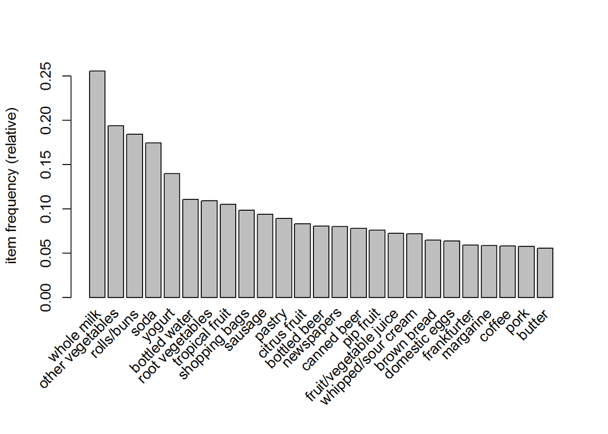

```r
itemFrequencyPlot(my_groceries, topN = 25)
```

Applying the apriori function to find the association rules within the items Generate all itemsets whose support >= minsup of 0.01 and Confidence is >= 0.5

```r
grocery_rules <-apriori(my_groceries,parameter=list(support=.01, confidence=.5, maxlen=4))
```

```
##
## Parameter specification:
##  confidence minval smax arem  aval originalSupport support minlen maxlen
##         0.5    0.1    1 none FALSE            TRUE    0.01      1      4
##  target   ext
##   rules FALSE
##
## Algorithmic control:
##  filter tree heap memopt load sort verbose
##     0.1 TRUE TRUE  FALSE TRUE    2    TRUE
##
## apriori - find association rules with the apriori algorithm
## version 4.21 (2004.05.09)        (c) 1996-2004   Christian Borgelt
## set item appearances ...[0 item(s)] done [0.00s].
## set transactions ...[169 item(s), 9835 transaction(s)] done [0.02s].
## sorting and recoding items ... [88 item(s)] done [0.00s].
## creating transaction tree ... done [0.03s].
## checking subsets of size 1 2 3 4 done [0.02s].
## writing ... [15 rule(s)] done [0.00s].
## creating S4 object  ... done [0.00s].
```

Analysing the rules which are generated from the apriori function

```r
inspect(grocery_rules)
```

```
##    lhs                     rhs                   support confidence     lift
## 1  {curd,
##     yogurt}             => {whole milk}       0.01006609  0.5823529 2.279125
## 2  {butter,
##     other vegetables}   => {whole milk}       0.01148958  0.5736041 2.244885
## 3  {domestic eggs,
##     other vegetables}   => {whole milk}       0.01230300  0.5525114 2.162336
## 4  {whipped/sour cream,
##     yogurt}             => {whole milk}       0.01087951  0.5245098 2.052747
## 5  {other vegetables,
##     whipped/sour cream} => {whole milk}       0.01464159  0.5070423 1.984385
## 6  {other vegetables,
##     pip fruit}          => {whole milk}       0.01352313  0.5175097 2.025351
## 7  {citrus fruit,
##     root vegetables}    => {other vegetables} 0.01037112  0.5862069 3.029608
## 8  {root vegetables,
##     tropical fruit}     => {other vegetables} 0.01230300  0.5845411 3.020999
## 9  {root vegetables,
##     tropical fruit}     => {whole milk}       0.01199797  0.5700483 2.230969
## 10 {tropical fruit,
##     yogurt}             => {whole milk}       0.01514997  0.5173611 2.024770
## 11 {root vegetables,
##     yogurt}             => {other vegetables} 0.01291307  0.5000000 2.584078
## 12 {root vegetables,
##     yogurt}             => {whole milk}       0.01453991  0.5629921 2.203354
## 13 {rolls/buns,
##     root vegetables}    => {other vegetables} 0.01220132  0.5020921 2.594890
## 14 {rolls/buns,
##     root vegetables}    => {whole milk}       0.01270971  0.5230126 2.046888
## 15 {other vegetables,
##     yogurt}             => {whole milk}       0.02226741  0.5128806 2.007235
```

```r
## Inspecting itemsets with lift value > 2
inspect(subset(grocery_rules, subset=lift > 2))
```

```
##    lhs                     rhs                   support confidence     lift
## 1  {curd,
##     yogurt}             => {whole milk}       0.01006609  0.5823529 2.279125
## 2  {butter,
##     other vegetables}   => {whole milk}       0.01148958  0.5736041 2.244885
## 3  {domestic eggs,
##     other vegetables}   => {whole milk}       0.01230300  0.5525114 2.162336
## 4  {whipped/sour cream,
##     yogurt}             => {whole milk}       0.01087951  0.5245098 2.052747
## 5  {other vegetables,
##     pip fruit}          => {whole milk}       0.01352313  0.5175097 2.025351
## 6  {citrus fruit,
##     root vegetables}    => {other vegetables} 0.01037112  0.5862069 3.029608
## 7  {root vegetables,
##     tropical fruit}     => {other vegetables} 0.01230300  0.5845411 3.020999
## 8  {root vegetables,
##     tropical fruit}     => {whole milk}       0.01199797  0.5700483 2.230969
## 9  {tropical fruit,
##     yogurt}             => {whole milk}       0.01514997  0.5173611 2.024770
## 10 {root vegetables,
##     yogurt}             => {other vegetables} 0.01291307  0.5000000 2.584078
## 11 {root vegetables,
##     yogurt}             => {whole milk}       0.01453991  0.5629921 2.203354
## 12 {rolls/buns,
##     root vegetables}    => {other vegetables} 0.01220132  0.5020921 2.594890
## 13 {rolls/buns,
##     root vegetables}    => {whole milk}       0.01270971  0.5230126 2.046888
## 14 {other vegetables,
##     yogurt}             => {whole milk}       0.02226741  0.5128806 2.007235
```

```r
## Inspecting itemsets with support value > 0.01 & confidence > 0.5
inspect(subset(grocery_rules, subset=support > 0.01 & confidence > 0.5))
```

```
##    lhs                     rhs                   support confidence     lift
## 1  {curd,
##     yogurt}             => {whole milk}       0.01006609  0.5823529 2.279125
## 2  {butter,
##     other vegetables}   => {whole milk}       0.01148958  0.5736041 2.244885
## 3  {domestic eggs,
##     other vegetables}   => {whole milk}       0.01230300  0.5525114 2.162336
## 4  {whipped/sour cream,
##     yogurt}             => {whole milk}       0.01087951  0.5245098 2.052747
## 5  {other vegetables,
##     whipped/sour cream} => {whole milk}       0.01464159  0.5070423 1.984385
## 6  {other vegetables,
##     pip fruit}          => {whole milk}       0.01352313  0.5175097 2.025351
## 7  {citrus fruit,
##     root vegetables}    => {other vegetables} 0.01037112  0.5862069 3.029608
## 8  {root vegetables,
##     tropical fruit}     => {other vegetables} 0.01230300  0.5845411 3.020999
## 9  {root vegetables,
##     tropical fruit}     => {whole milk}       0.01199797  0.5700483 2.230969
## 10 {tropical fruit,
##     yogurt}             => {whole milk}       0.01514997  0.5173611 2.024770
## 11 {root vegetables,
##     yogurt}             => {whole milk}       0.01453991  0.5629921 2.203354
## 12 {rolls/buns,
##     root vegetables}    => {other vegetables} 0.01220132  0.5020921 2.594890
## 13 {rolls/buns,
##     root vegetables}    => {whole milk}       0.01270971  0.5230126 2.046888
## 14 {other vegetables,
##     yogurt}             => {whole milk}       0.02226741  0.5128806 2.007235
```

```r
## Inspecting itemsets with confidence > 0.5
inspect(subset(grocery_rules, subset=confidence > 0.5))
```

```
##    lhs                     rhs                   support confidence     lift
## 1  {curd,
##     yogurt}             => {whole milk}       0.01006609  0.5823529 2.279125
## 2  {butter,
##     other vegetables}   => {whole milk}       0.01148958  0.5736041 2.244885
## 3  {domestic eggs,
##     other vegetables}   => {whole milk}       0.01230300  0.5525114 2.162336
## 4  {whipped/sour cream,
##     yogurt}             => {whole milk}       0.01087951  0.5245098 2.052747
## 5  {other vegetables,
##     whipped/sour cream} => {whole milk}       0.01464159  0.5070423 1.984385
## 6  {other vegetables,
##     pip fruit}          => {whole milk}       0.01352313  0.5175097 2.025351
## 7  {citrus fruit,
##     root vegetables}    => {other vegetables} 0.01037112  0.5862069 3.029608
## 8  {root vegetables,
##     tropical fruit}     => {other vegetables} 0.01230300  0.5845411 3.020999
## 9  {root vegetables,
##     tropical fruit}     => {whole milk}       0.01199797  0.5700483 2.230969
## 10 {tropical fruit,
##     yogurt}             => {whole milk}       0.01514997  0.5173611 2.024770
## 11 {root vegetables,
##     yogurt}             => {whole milk}       0.01453991  0.5629921 2.203354
## 12 {rolls/buns,
##     root vegetables}    => {other vegetables} 0.01220132  0.5020921 2.594890
## 13 {rolls/buns,
##     root vegetables}    => {whole milk}       0.01270971  0.5230126 2.046888
## 14 {other vegetables,
##     yogurt}             => {whole milk}       0.02226741  0.5128806 2.007235
```

There is a high propensity for people buying “Other Vegetables and yogurt” since they have a high support value of 0.02226741.

Similarily, for people buying “citrus fruit and root vegetables”, they are more likely to purchase other vegetables" as well since this association has a high confidence value of 0.5862069.

Plotting the confidence versus support graph and analysing the support and confidence values.

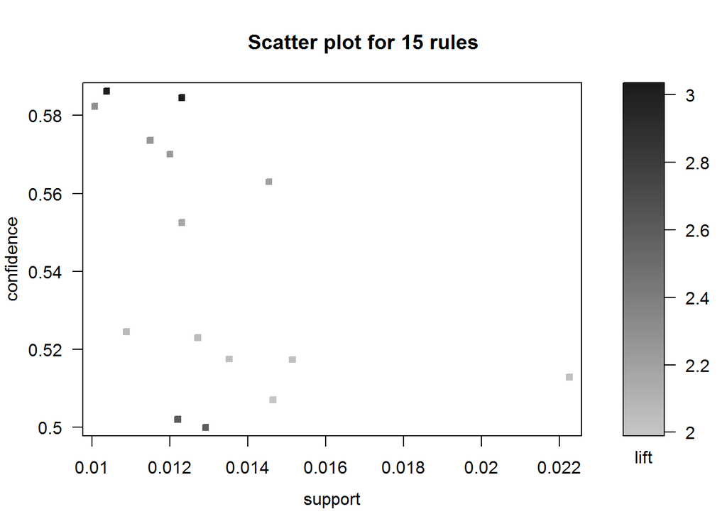

```r
library(arulesViz)
plot(grocery_rules)
```

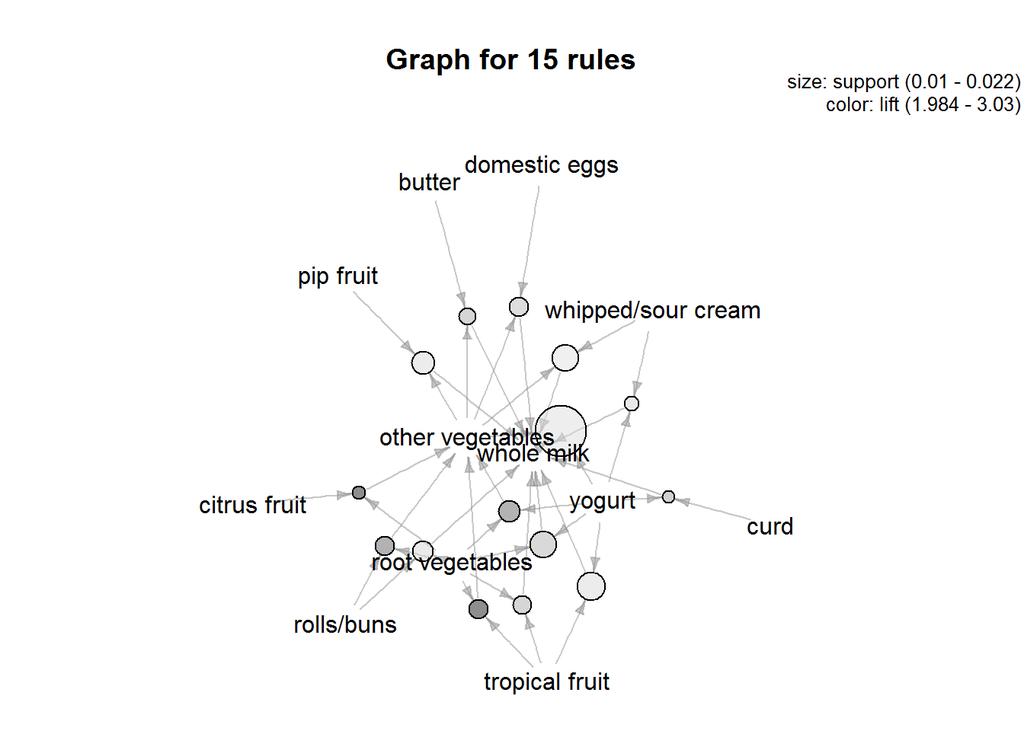

```r
plot(grocery_rules, method="graph", control=list(type="items"))
```